# Title Telomere Project Analysis_Cleaned Code

### Plot out changes in DNMT3A

```r
(dsHits <- topTable(EbFit.DNMT3A,n=12,
                    coef = grep("TS", colnames(coef(EbFit.DNMT3A)))))
```

```
##                   logFC    AveExpr         t      P.Value   adj.P.Val
## cg11779362  0.050567751 0.56028474  4.322534 6.514219e-05 0.005732513
## cg08485187 -0.032738338 0.70714950 -3.820844 3.400984e-04 0.014964327
## cg13558695 -0.033460073 0.67137933 -2.785527 7.352397e-03 0.215502518
## cg23009818 -0.019364701 0.72559678 -2.675902 9.795569e-03 0.215502518
## cg20669908 -0.015879412 0.62254178 -2.531230 1.425008e-02 0.234833138
## cg17742416 -0.017219661 0.78386954 -2.400298 1.985211e-02 0.234833138
## cg00886730 -0.007120803 0.91075549 -2.332872 2.340387e-02 0.234833138
## cg03980035 -0.036137517 0.71486075 -2.323704 2.385782e-02 0.234833138
## cg00856404 -0.015657660 0.62276692 -2.233020 2.970623e-02 0.234833138
## cg03208817 -0.003515787 0.04537107 -2.225641 3.014926e-02 0.234833138
## cg05896193 -0.016927504 0.76535268 -2.190179 3.276193e-02 0.234833138
## cg23200404 -0.004333872 0.92797980 -2.184862 3.317032e-02 0.234833138
##                     B
## cg11779362 -0.3287541
## cg08485187 -1.9256862
## cg13558695 -4.8115479
## cg23009818 -5.0897959
## cg20669908 -5.4311055
## cg17742416 -5.7259182
## cg00886730 -5.8753577
## cg03980035 -5.8941817
## cg00856404 -6.0839818
## cg03208817 -6.1016966
## cg05896193 -6.1749035
## cg23200404 -6.1857935
```

```r
print(dsHits)
```

```
##                   logFC    AveExpr         t      P.Value   adj.P.Val
## cg11779362  0.050567751 0.56028474  4.322534 6.514219e-05 0.005732513
## cg08485187 -0.032738338 0.70714950 -3.820844 3.400984e-04 0.014964327
## cg13558695 -0.033460073 0.67137933 -2.785527 7.352397e-03 0.215502518
## cg23009818 -0.019364701 0.72559678 -2.675902 9.795569e-03 0.215502518
## cg20669908 -0.015879412 0.62254178 -2.531230 1.425008e-02 0.234833138
## cg17742416 -0.017219661 0.78386954 -2.400298 1.985211e-02 0.234833138
## cg00886730 -0.007120803 0.91075549 -2.332872 2.340387e-02 0.234833138
## cg03980035 -0.036137517 0.71486075 -2.323704 2.385782e-02 0.234833138
## cg00856404 -0.015657660 0.62276692 -2.233020 2.970623e-02 0.234833138
## cg03208817 -0.003515787 0.04537107 -2.225641 3.014926e-02 0.234833138
## cg05896193 -0.016927504 0.76535268 -2.190179 3.276193e-02 0.234833138
## cg23200404 -0.004333872 0.92797980 -2.184862 3.317032e-02 0.234833138
##                     B
## cg11779362 -0.3287541
## cg08485187 -1.9256862
## cg13558695 -4.8115479
## cg23009818 -5.0897959
## cg20669908 -5.4311055
## cg17742416 -5.7259182
## cg00886730 -5.8753577
## cg03980035 -5.8941817
## cg00856404 -6.0839818
## cg03208817 -6.1016966
## cg05896193 -6.1749035
## cg23200404 -6.1857935
```

```r
interest<-dsHits[c(1:2),]

fData_interest<-merge(fData,interest,by='row.names')

##subset prDat with these hits
interest_dat<-PROJECT[c('cg11779362','cg08485187'),]

##Restructure data
interest_dat<-as.data.frame(t(interest_dat))
interest_dat<-merge(interest_dat,Des,by ='row.names')

##Do these sites correlate?
  ##order by map info
topDNMT3A<-fData_interest[order(fData_interest$MAPINF0-1),]
rownames(topDNMT3A)<-topDNMT3A$Row.names

  ##subset from project
DNMT3A.PROJECT<-as.data.frame(DNMT3A.PROJECT)
topDNMT3A.PROJECT<-DNMT3A.PROJECT[which(rownames(DNMT3A.PROJECT) %in% rownames(topDNMT3A)),]

topDNMT3A.betas<-m2beta(topDNMT3A.PROJECT)
topDNMT3A.betas<-as.data.frame(topDNMT3A.betas)

##Make sure the betas are in the same map order
MapInfo<-topDNMT3A$MAPINF0-1
MapInfo<-as.data.frame(MapInfo)
rownames(MapInfo)<-rownames(topDNMT3A)

topDNMT3A.betas_ordered<-merge(topDNMT3A.betas,MapInfo,by='row.names')
topDNMT3A.betas_ordered<-topDNMT3A.betas_ordered[order(topDNMT3A.betas_ordered$MapInfo),]
rownames(topDNMT3A.betas_ordered)<-topDNMT3A.betas_ordered$Row.names
rownames(topDNMT3A.betas_ordered)==rownames(topDNMT3A)
```

```
## [1] TRUE TRUE
```

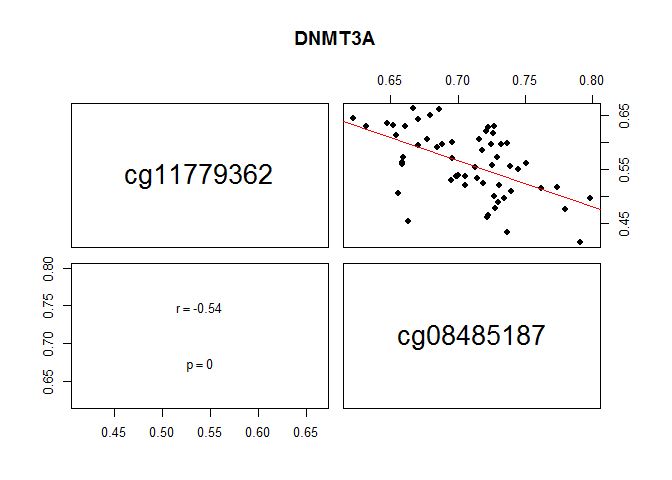

```r
topDNMT3A.betas_ordered$Row.names<-NULL
topDNMT3A.betas_ordered$MapInfo<-NULL
#write.table(topDNMT3A.betas_ordered, file="topDNMT3A.betas.txt")

ID<-t(topDNMT3A.betas_ordered)
pairs(ID[,c(1:2)],main="DNMT3A",lower.panel=panel.sse,upper.panel=panel.lm)
```

```r
##These sites correlate with one another

##How many of these hits meet a minimum change in DNAm >0.05
##Setting the FDR
cutoff.p = 0.05  # FDR threshold
hits_FDR = rownames(dsHits)[dsHits$adj.P.Val < cutoff.p]

##Pulling out change in DNAm
PROJECT_Beta<-m2beta(DNMT3A.PROJECT)

fit_beta = lmFit(PROJECT_Beta,DesMat.DNMT3A)
Ebfit_beta = eBayes(fit_beta)
ttbeta_all = topTable(Ebfit_beta, n = Inf)
```

```
## Removing intercept from test coefficients
```

```r
##Setting delta beta threshold
thresh = 0.02  # delta beta threshold
delta_beta= rownames(ttbeta_all)[abs(ttbeta_all$TS) > thresh]

##Where do all these hits intersect?
delta_beta_intercept= intersect(delta_beta,hits_FDR)
print(delta_beta_intercept)
```

```
## [1] "cg11779362" "cg08485187"
```

```r
##This leaves us with 2 hits cg11779362-just under the DB>0.049

##Subset out all our hits from ttbeta_all
hits<-c('cg11779362')
Our_hits<-ttbeta_all[which(rownames(ttbeta_all) %in% hits),]
print(Our_hits)
```

```
##                    TS          GA    SEXMALE   AveExpr        F
## cg11779362 0.05056775 0.006004437 -0.0251336 0.5602847 14.98916
##                 P.Value    adj.P.Val
## cg11779362 2.982248e-07 2.624378e-05
```

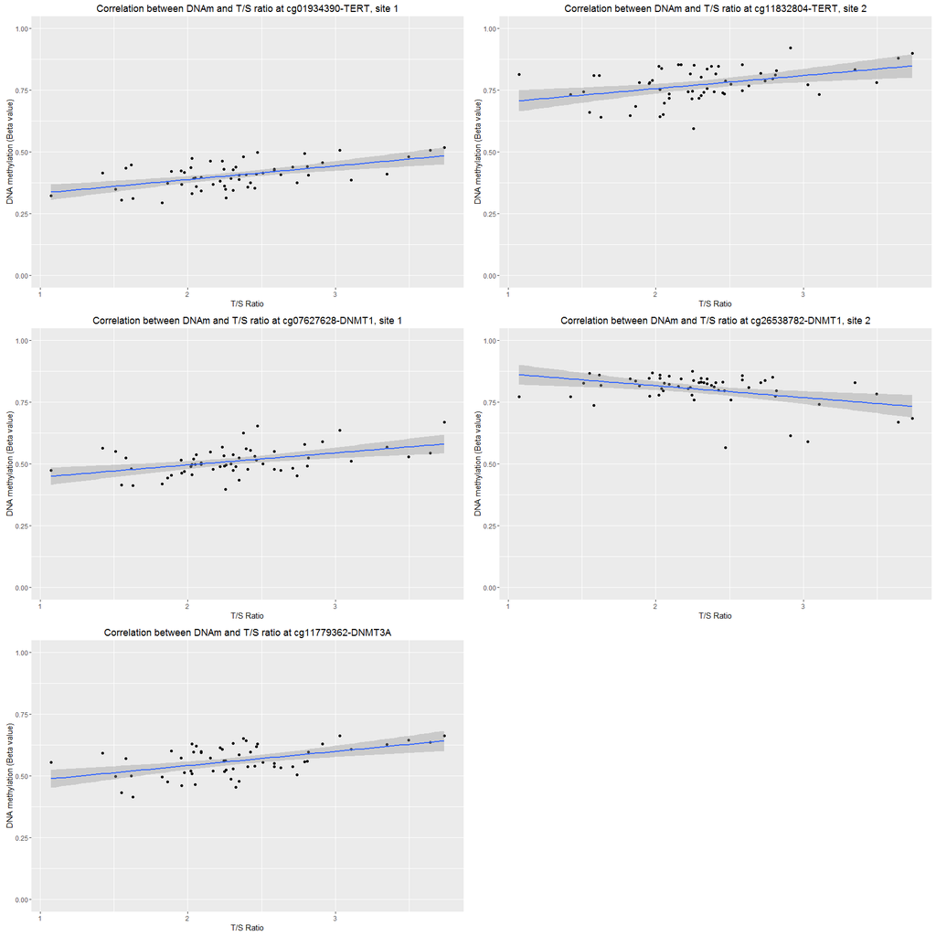

```r
##Subset columns of interest (GROUP,TS,m val,SEX,GA)
cg11779362<-subset(interest_dat[,c(2,5,8,13,15)])

##calculate beta values
cg11779362$beta<-m2beta(cg11779362$cg11779362)

##Plot the hit CpGs
##cg19977628
DNMT3A<-ggplot(cg11779362,aes(TS,beta))+
  ylim(0,1.0)+
  geom_point()+
  stat_smooth(method="lm",se=T)+
  xlab("T/S Ratio") +
   ylab("DNA methylation (Beta value)") +
   ggtitle("Correlation between DNAm and T/S ratio at cg11779362-DNMT3A")
##0.051 change with every 1 point change in TL p=0.004

##All graphs together- Candidate gene approach
grid.arrange(TERT1,TERT2,DNMT1_1,DNMT1_2,DNMT3A, ncol=2)
```

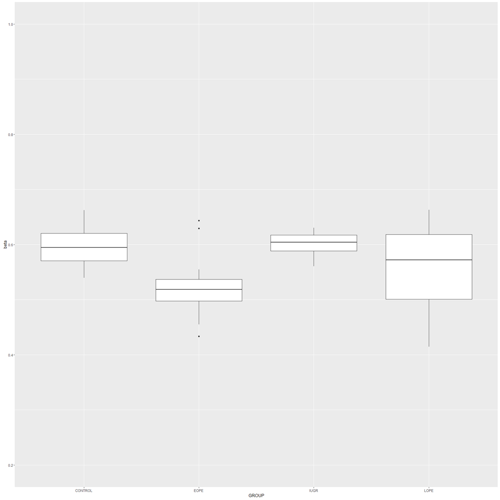

```r
## Do we see differences between EOPE, LOPE, IUGR and controls at these sites?
DNMT3A_BOXPLOT<-ggplot(cg11779362, aes(x=GROUP, y=beta)) + geom_boxplot() +
    guides(fill=FALSE)+ylim(0.2,1)

DNMT3A_BOXPLOT
```

```r
DNMT3Ahits<-DNMT3A.PROJECT[c('cg11779362'),]
DNMT3Ahits<-t(DNMT3Ahits)
DNMT3Ahits<-as.data.frame(DNMT3Ahits)

DNMT3Ahits_Dat<-merge(DNMT3Ahits,T.Dat,by='row.names')

##ANOVA to compare DNAm at cg11779362 between pathology
amod <- aov(cg11779362~GROUP+SEX+GA, data = DNMT3Ahits_Dat)
cht <- glht(amod, linfct = mcp(GROUP = "Tukey"))

summary(cht, test = univariate())
```

```
##
##   Simultaneous Tests for General Linear Hypotheses
##
## Multiple Comparisons of Means: Tukey Contrasts
##
##
## Fit: aov(formula = cg11779362 ~ GROUP + SEX + GA, data = DNMT3Ahits_Dat)
##
## Linear Hypotheses:
##                     Estimate Std. Error t value Pr(>|t|)
## EOPE - CONTROL == 0 -0.29038    0.11926  -2.435   0.0184 *
## IUGR - CONTROL == 0 -0.03427    0.13589  -0.252   0.8019
## LOPE - CONTROL == 0 -0.26074    0.11359  -2.295   0.0258 *
## IUGR - EOPE == 0     0.25611    0.14582   1.756   0.0849 .
## LOPE - EOPE == 0     0.02964    0.12688   0.234   0.8162
## LOPE - IUGR == 0    -0.22647    0.12886  -1.757   0.0847 .
## ---
## Signif. codes:  0 '***' 0.001 '**' 0.01 '*' 0.05 '.' 0.1 ' ' 1
## (Univariate p values reported)
```

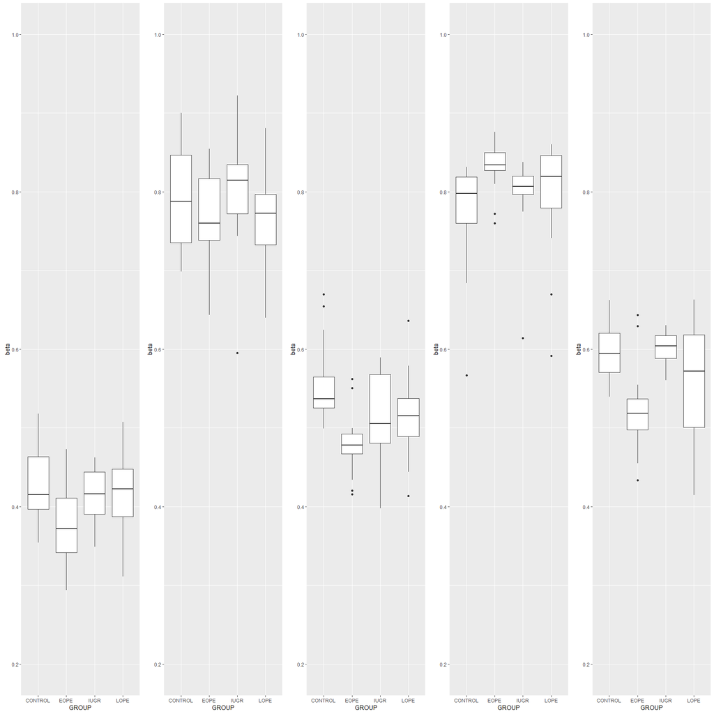

```r
##All boxplot
grid.arrange(TERT1_BOXPLOT,TERT2_BOXPLOT,DNMT11_BOXPLOT,DNMT12_BOXPLOT,DNMT3A_BOXPLOT, nrow=1)
```

Questions 3a.Does DNAm at DNMT1,3a and TERT differ in EOPE,LOPE and IUGR compared to controls?

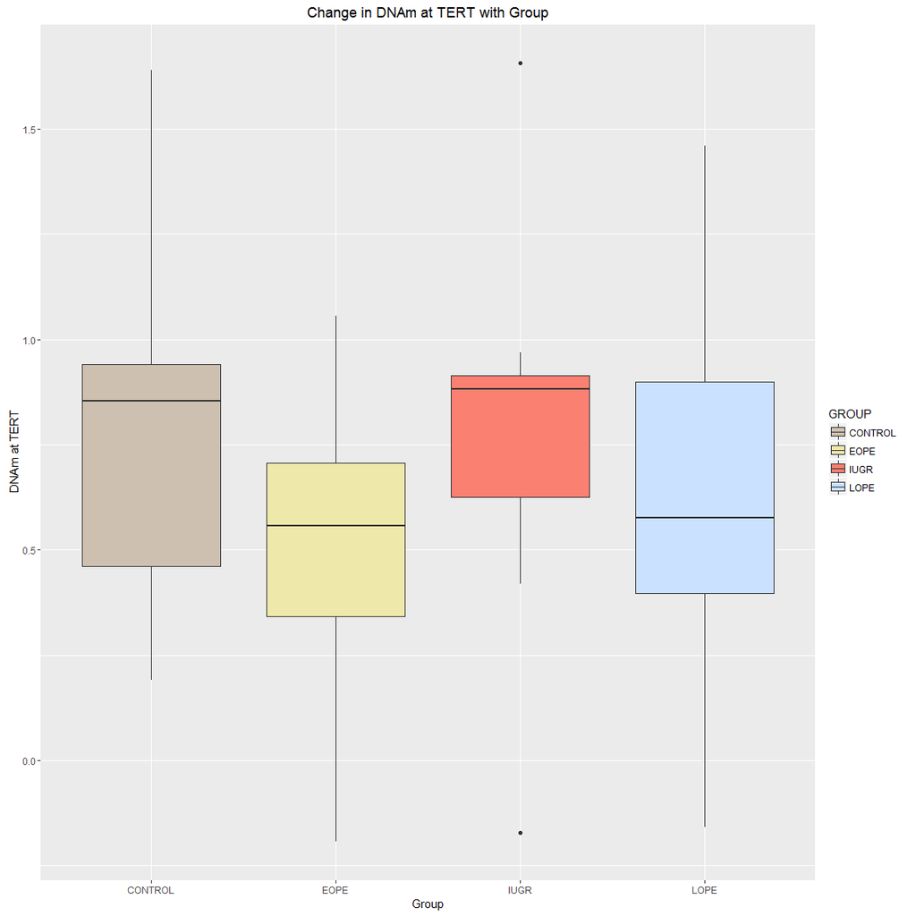

```r
DNAm_TL_Data<-read.table("DNAm_TL_Data.txt",header=T)

##TERT
(GRPvTS<- ggplot(DNAm_TL_Data, aes(GROUP, TERTavg,fill=GROUP)) +
   geom_boxplot()+scale_fill_manual(values=unique(grp.col)))+
   theme_grey() +
   xlab("Group") +
   ylab("DNAm at TERT") +
   ggtitle("Change in DNAm at TERT with Group")
```

```r
amod <- aov(TERTavg~GROUP+SEX+GA, data = DNAm_TL_Data)
cht <- glht(amod, linfct = mcp(GROUP = "Tukey"))

summary(cht, test = univariate())
```

```
##
##   Simultaneous Tests for General Linear Hypotheses
##
## Multiple Comparisons of Means: Tukey Contrasts
##
##
## Fit: aov(formula = TERTavg ~ GROUP + SEX + GA, data = DNAm_TL_Data)
##
## Linear Hypotheses:
##                     Estimate Std. Error t value Pr(>|t|)
## EOPE - CONTROL == 0 -0.22861    0.15935  -1.435    0.157
## IUGR - CONTROL == 0 -0.00855    0.18157  -0.047    0.963
## LOPE - CONTROL == 0 -0.16132    0.15178  -1.063    0.293
## IUGR - EOPE == 0     0.22006    0.19484   1.129    0.264
## LOPE - EOPE == 0     0.06729    0.16954   0.397    0.693
## LOPE - IUGR == 0    -0.15277    0.17218  -0.887    0.379
## (Univariate p values reported)
```

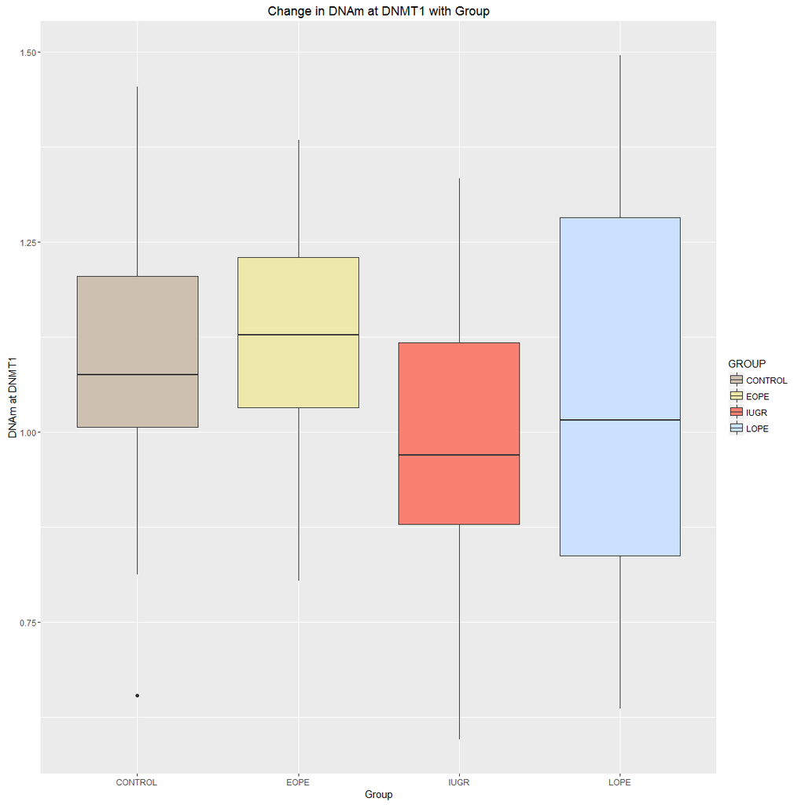

```r
##No significant different in average TERT DNAm between pathology groups

##DNMT1
(GRPvTS<- ggplot(DNAm_TL_Data, aes(GROUP, DNMT1avg,fill=GROUP)) +
   geom_boxplot()+scale_fill_manual(values=unique(grp.col)))+
   theme_grey() +
   xlab("Group") +
   ylab("DNAm at DNMT1") +
   ggtitle("Change in DNAm at DNMT1 with Group")
```

```r
amod <- aov(DNMT1avg~GROUP+SEX+GA, data = DNAm_TL_Data)
cht <- glht(amod, linfct = mcp(GROUP = "Tukey"))

summary(cht, test = univariate())
```

```
##
##   Simultaneous Tests for General Linear Hypotheses
##
## Multiple Comparisons of Means: Tukey Contrasts
##
##
## Fit: aov(formula = DNMT1avg ~ GROUP + SEX + GA, data = DNAm_TL_Data)
##
## Linear Hypotheses:
##                      Estimate Std. Error t value Pr(>|t|)
## EOPE - CONTROL == 0  0.017044   0.084058   0.203    0.840
## IUGR - CONTROL == 0 -0.070340   0.095778  -0.734    0.466
## LOPE - CONTROL == 0  0.005938   0.080060   0.074    0.941
## IUGR - EOPE == 0    -0.087384   0.102776  -0.850    0.399
## LOPE - EOPE == 0    -0.011106   0.089431  -0.124    0.902
## LOPE - IUGR == 0     0.076278   0.090824   0.840    0.405
## (Univariate p values reported)
```

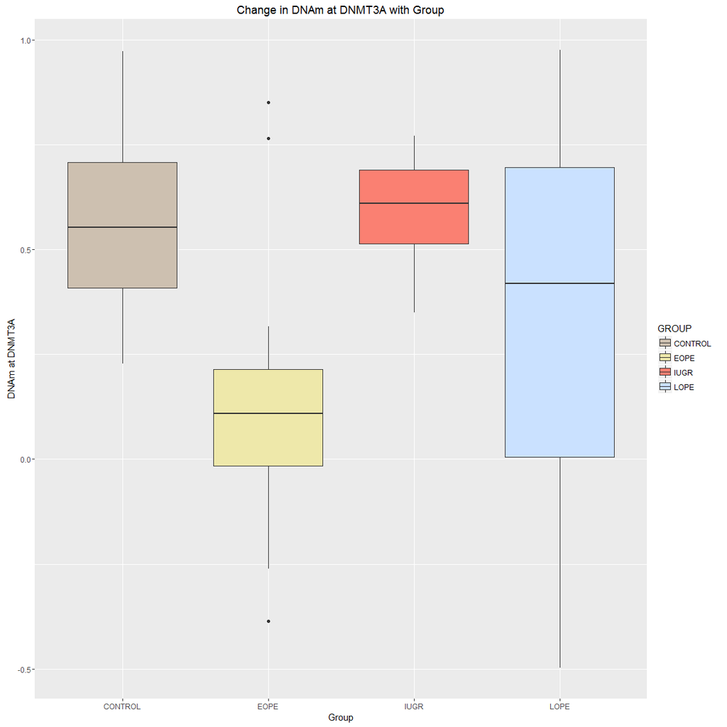

```r
##No significantlt difference in average DNMT1 DNAm between pathology groups

##DNMT3A
(GRPvTS<- ggplot(DNAm_TL_Data, aes(GROUP, cg11779362,fill=GROUP)) +
   geom_boxplot()+scale_fill_manual(values=unique(grp.col)))+
   theme_grey() +
   xlab("Group") +
   ylab("DNAm at DNMT3A") +
   ggtitle("Change in DNAm at DNMT3A with Group")
```

```r
amod <- aov(cg11779362~GROUP+SEX+GA, data = DNAm_TL_Data)
cht <- glht(amod, linfct = mcp(GROUP = "Tukey"))

summary(cht, test = univariate())
```

```
##
##   Simultaneous Tests for General Linear Hypotheses
##
## Multiple Comparisons of Means: Tukey Contrasts
##
##
## Fit: aov(formula = cg11779362 ~ GROUP + SEX + GA, data = DNAm_TL_Data)
##
## Linear Hypotheses:
##                     Estimate Std. Error t value Pr(>|t|)
## EOPE - CONTROL == 0 -0.29038    0.11926  -2.435   0.0184 *
## IUGR - CONTROL == 0 -0.03427    0.13589  -0.252   0.8019
## LOPE - CONTROL == 0 -0.26074    0.11359  -2.295   0.0258 *
## IUGR - EOPE == 0     0.25611    0.14582   1.756   0.0849 .
## LOPE - EOPE == 0     0.02964    0.12688   0.234   0.8162
## LOPE - IUGR == 0    -0.22647    0.12886  -1.757   0.0847 .
## ---
## Signif. codes:  0 '***' 0.001 '**' 0.01 '*' 0.05 '.' 0.1 ' ' 1
## (Univariate p values reported)
```

```r
##Significant different at cg11779362 between EOPE and control, and LOPE and control
```

Question 4: In a control population do we see association between TL and DNAm

```r
##load('PROJECT.Telomere.Final.Dnam_Data.RData')

##Subset out control samples
Des.Con<-subset(Des,GROUP=="CONTROL")
rownames(Des.Con)
```

```
##  [1] "PL104" "PL112" "PL32"  "PL33"  "PL38"  "PM136" "PM153" "PM161"
##  [9] "PM17"  "PM205" "PM263" "PM77"  "PM87"
```

```r
PROJECT.Con<-PROJECT[, which(colnames(PROJECT)  %in% rownames(Des.Con))]
dim(PROJECT.Con)
```

```
## [1] 441093     13
```

```r
rownames(Des.Con)==colnames(PROJECT.Con)
```

```
##  [1] TRUE TRUE TRUE TRUE TRUE TRUE TRUE TRUE TRUE TRUE TRUE TRUE TRUE
```

```r
##13 control samples

##Limma
DesMat <- model.matrix(~TS+GA+SEX, Des.Con)

##Pull out m-values
mDat<-PROJECT.Con
Fit <- lmFit(mDat, DesMat)
EbFit <- eBayes(Fit)
topTable(EbFit,coef="TS")
```

```
##                 logFC   AveExpr         t      P.Value adj.P.Val         B
## cg25864523 -1.9163602 -2.630643 -8.196789 2.081449e-06 0.4214007 -3.155830
## cg20897936 -1.2831415 -1.169358 -8.013620 2.652597e-06 0.4214007 -3.168736
## cg15880846 -2.0880010 -3.679370 -7.955758 2.866067e-06 0.4214007 -3.172953
## cg19826026 -0.9057846 -3.038086 -7.535752 5.086926e-06 0.5609518 -3.205737
## cg17115250 -2.0846149 -2.251647 -7.125459 9.097797e-06 0.8025949 -3.241849
## cg08251815 -1.1430262 -1.493172 -6.370265 2.808209e-05 0.9999673 -3.320998
## cg21800258 -2.0324567 -1.938608 -6.350038 2.897322e-05 0.9999673 -3.323376
## cg10684686 -1.9921736 -1.452656 -6.329064 2.992892e-05 0.9999673 -3.325858
## cg05828030 -1.0025718  2.144408 -6.306534 3.099279e-05 0.9999673 -3.328541
## cg23866755 -1.0886458 -5.084859 -6.209653 3.604412e-05 0.9999673 -3.340293
```

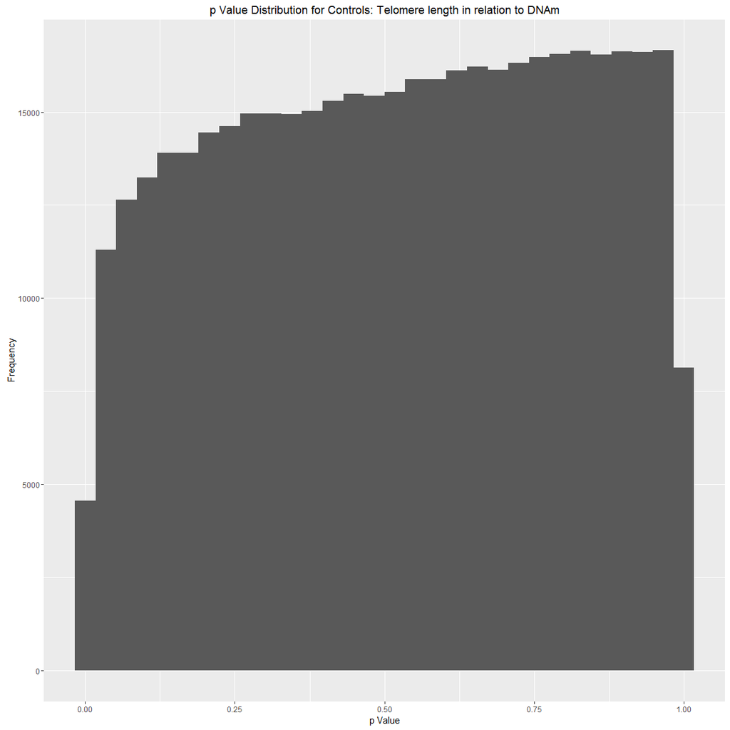

```r
##In Controls we do not get any hits where TL is associated with DNAm adjusting for GA, sex and multiple comparisons. a corrected p value of 0.42 is the lowest we get

##For p-value distribution
tt<-topTable(EbFit,coef="TS", n=Inf)
ggplot(tt, aes(x =P.Value)) +
 geom_histogram() +
 theme_grey() +
   xlab("p Value") +
   ylab("Frequency") +
   ggtitle("p Value Distribution for Controls: Telomere length in relation to DNAm")
```

```r
##No hits or skew to the left
```

As we saw no difference in telomere length between patholgy and control, we added all of the samples to the model to increase power, then looked for changes in DNAm associated with TL

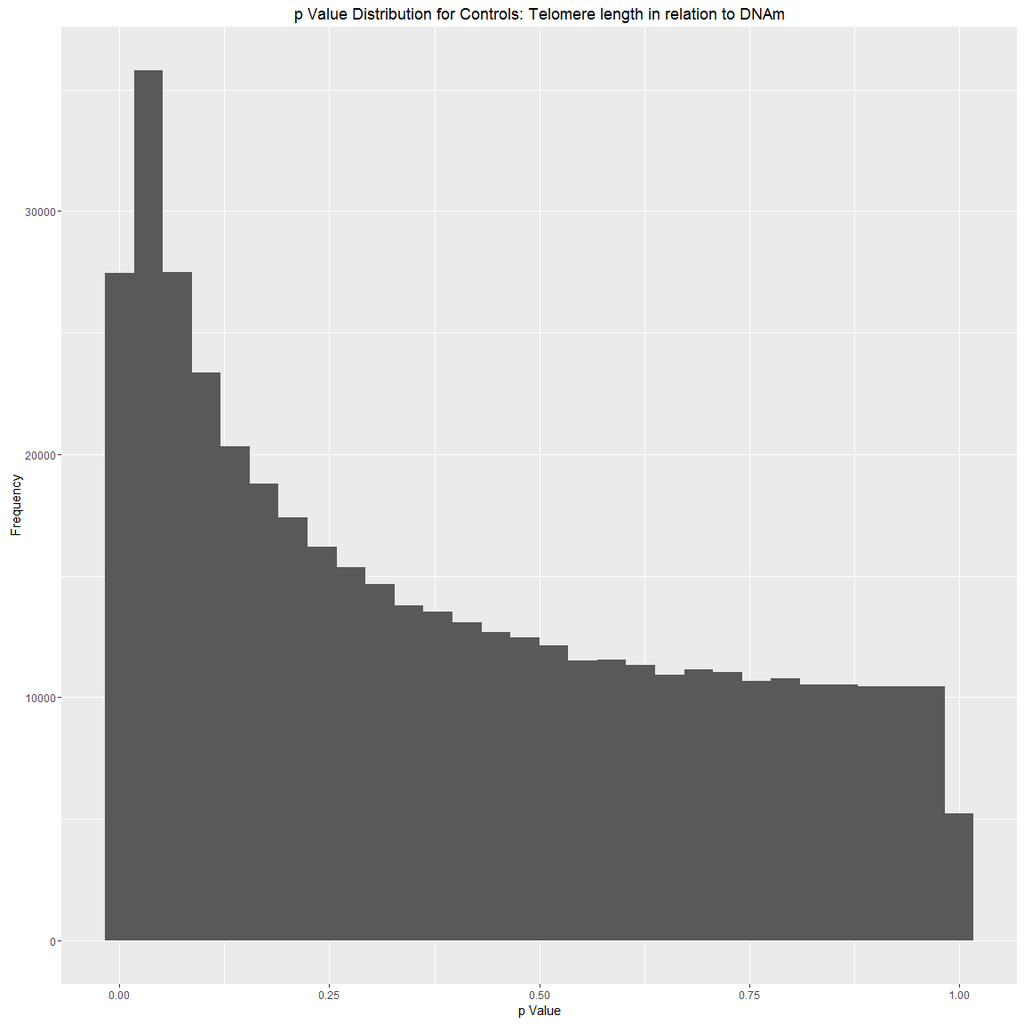

```r
##Limma
DesMat <- model.matrix(~TS+GA+SEX, Des)

##Pull out m-values
mDat<-PROJECT
Fit <- lmFit(mDat, DesMat)
EbFit <- eBayes(Fit)
ttTS<-topTable(EbFit,coef="TS")
##0 significant genes

##For p-value distribution
tt<-topTable(EbFit,coef="TS", n=Inf)
ggplot(tt, aes(x =P.Value)) +
 geom_histogram() +
 theme_grey() +
   xlab("p Value") +
   ylab("Frequency") +
   ggtitle("p Value Distribution for Controls: Telomere length in relation to DNAm")
```

```r
##Pull hits
(dsHits <- topTable(EbFit,
                    coef = grep("TS", colnames(coef(EbFit)))))
```

```
##                 logFC    AveExpr         t      P.Value  adj.P.Val
## cg20771622  0.3656604 -0.2105065  5.884284 2.170231e-07 0.07544249
## cg22675207  0.6029823  0.8233339  5.684454 4.597204e-07 0.07544249
## cg17921080  0.3944421 -3.6853153  5.644656 5.334828e-07 0.07544249
## cg13633026  0.4473889 -1.4590328  5.576395 6.882021e-07 0.07544249
## cg26314823  0.3329230  2.5956764  5.518007 8.551767e-07 0.07544249
## cg04156383  0.3358650  0.3495476  5.334144 1.688262e-06 0.10644839
## cg01054775  0.4175165  1.1749314  5.256817 2.243073e-06 0.10644839
## cg01513157  0.7558772 -3.1960677  5.239828 2.387184e-06 0.10644839
## cg02893212  0.4350138 -0.8023938  5.236811 2.413720e-06 0.10644839
## cg22475358 -0.2662715  0.1394556 -5.220285 2.564268e-06 0.10644839
##                   B
## cg20771622 6.207338
## cg22675207 5.586009
## cg17921080 5.462659
## cg13633026 5.251445
## cg26314823 5.071156
## cg04156383 4.506005
## cg01054775 4.269632
## cg01513157 4.217814
## cg02893212 4.208614
## cg22475358 4.158256
```

```r
print(dsHits)
```

```
##                 logFC    AveExpr         t      P.Value  adj.P.Val
## cg20771622  0.3656604 -0.2105065  5.884284 2.170231e-07 0.07544249
## cg22675207  0.6029823  0.8233339  5.684454 4.597204e-07 0.07544249
## cg17921080  0.3944421 -3.6853153  5.644656 5.334828e-07 0.07544249
## cg13633026  0.4473889 -1.4590328  5.576395 6.882021e-07 0.07544249
## cg26314823  0.3329230  2.5956764  5.518007 8.551767e-07 0.07544249
## cg04156383  0.3358650  0.3495476  5.334144 1.688262e-06 0.10644839
## cg01054775  0.4175165  1.1749314  5.256817 2.243073e-06 0.10644839
## cg01513157  0.7558772 -3.1960677  5.239828 2.387184e-06 0.10644839
## cg02893212  0.4350138 -0.8023938  5.236811 2.413720e-06 0.10644839
## cg22475358 -0.2662715  0.1394556 -5.220285 2.564268e-06 0.10644839
##                   B
## cg20771622 6.207338
## cg22675207 5.586009
## cg17921080 5.462659
## cg13633026 5.251445
## cg26314823 5.071156
## cg04156383 4.506005
## cg01054775 4.269632
## cg01513157 4.217814
## cg02893212 4.208614
## cg22475358 4.158256
```

Question 5. Do we see changes in DNAm associated with TL on the XY chromosome?

```r
load('PE_IUGR_PROJECT.xy.RData')##Loading DNAm data from the XY chromosome
dim(PROJECT.xy)
```

```
## Features  Samples
##    11273      110
```

```r
XY<-as.matrix(exprs(PROJECT.xy))

XY<-XY[, which(colnames(XY)  %in% colnames(PROJECT))]
colnames(XY)  %in% rownames(T.Dat)
```

```
##  [1] TRUE TRUE TRUE TRUE TRUE TRUE TRUE TRUE TRUE TRUE TRUE TRUE TRUE TRUE
## [15] TRUE TRUE TRUE TRUE TRUE TRUE TRUE TRUE TRUE TRUE TRUE TRUE TRUE TRUE
## [29] TRUE TRUE TRUE TRUE TRUE TRUE TRUE TRUE TRUE TRUE TRUE TRUE TRUE TRUE
## [43] TRUE TRUE TRUE TRUE TRUE TRUE TRUE TRUE TRUE TRUE TRUE TRUE TRUE TRUE
## [57] TRUE TRUE
```

```r
Des<-T.Dat[which(rownames(T.Dat) %in% colnames(XY)),]

##Linear regression looking for changes in DNAm of CHR XY in association with TL
DesMat <- model.matrix(~TS+GA+SEX, Des)

##Pull out m-values
mDat<-XY

Fit <- lmFit(mDat, DesMat)
EbFit <- eBayes(Fit)
ttTS<-topTable(EbFit,coef="TS")
print(ttTS)
```

```
##                 logFC     AveExpr         t     P.Value adj.P.Val
## cg19341307  0.5895017 -2.63310614  3.213516 0.002154974 0.9380939
## cg00060882 -0.2587982 -1.86683486 -2.962396 0.004439534 0.9380939
## cg00765686 -0.2965117 -2.14254777 -2.905094 0.005210503 0.9380939
## cg01747278 -0.3977825  2.78242210 -2.865544 0.005813132 0.9380939
## cg17725109 -0.3981405  3.04571907 -2.858469 0.005927514 0.9380939
## cg12147998  0.3952526 -3.27556529  2.845287 0.006146202 0.9380939
## cg02055404 -0.4358535  0.26087880 -2.794477 0.007060675 0.9380939
## cg10066681  0.4068213  0.09611192  2.730124 0.008398653 0.9380939
## cg06116593 -0.3994595  2.53469501 -2.691944 0.009298704 0.9380939
## cg27189967 -0.5531645  0.77382298 -2.676658 0.009683214 0.9380939
##                    B
## cg19341307 -3.466702
## cg00060882 -3.638773
## cg00765686 -3.677010
## cg01747278 -3.703160
## cg17725109 -3.707817
## cg12147998 -3.716476
## cg02055404 -3.749638
## cg10066681 -3.791135
## cg06116593 -3.815482
## cg27189967 -3.825172
```

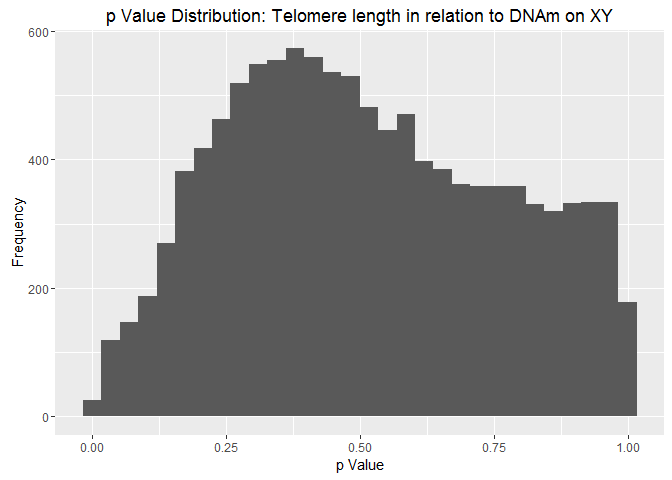

```r
##0 significant genes

##For p-value distribution
tt<-topTable(EbFit,coef="TS", n=Inf)
ggplot(tt, aes(x =P.Value)) +
 geom_histogram() +
 theme_grey() +
   xlab("p Value") +
   ylab("Frequency") +
   ggtitle("p Value Distribution: Telomere length in relation to DNAm on XY")
```

Question 8- If I split my data into male and female and look for association between DNAm and TL is each fetal sex, are their sex dependent associations?

```r
##Subset Des
Des_Fe<-subset(Des,SEX=="FEMALE")##27
summary(Des_Fe$GROUP)
```

```
## CONTROL    EOPE    IUGR    LOPE
##       7       7       5       8
```

```r
Des_M<-subset(Des, SEX=="MALE")
summary(Des_M$GROUP)
```

```
## CONTROL    EOPE    IUGR    LOPE
##       6      13       3       9
```

```r
##Subset Data
PROJECT.Fe<-PROJECT[,which(colnames(PROJECT) %in% rownames(Des_Fe))]##27 females

PROJECT.M<-PROJECT[,which(colnames(PROJECT) %in% rownames(Des_M))]##31 males
```

Looking at Females first Run Model Find hits-Females

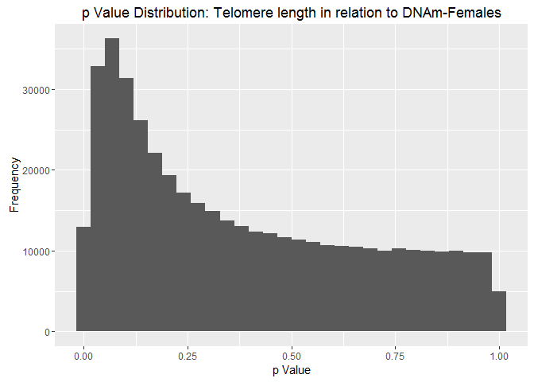

```r
##Linear regression looking for associated between DNAm and TL in females
DesMat <- model.matrix(~0+TS+GA, Des_Fe)##No need to correct for sex, only looking at females

##Pull out m-values
mDat<-PROJECT.Fe

Fit <- lmFit(mDat, DesMat)
EbFit <- eBayes(Fit)
ttTS<-topTable(EbFit,coef="TS", n = Inf)
##0 meet FDR

##For p-value distribution
tt<-topTable(EbFit,coef="TS", n=Inf)
ggplot(tt, aes(x =P.Value)) +
 geom_histogram() +
 theme_grey() +
   xlab("p Value") +
   ylab("Frequency") +
   ggtitle("p Value Distribution: Telomere length in relation to DNAm-Females")
```

Do they meet the delta beta threshold? Do any of these sites meet a delta beta threshold?

```r
## Do any sites meet an FDR<0.05, and delta beta>0.05
##Setting the FDR
cutoff.p = 0.05  # FDR threshold
hits_FDR = rownames(ttTS)[ttTS$adj.P.Val < cutoff.p]

##Pulling out change in DNAm
PROJECT.Fe_Beta<-m2beta(PROJECT.Fe)

fit_beta = lmFit(PROJECT.Fe_Beta, DesMat)
Ebfit_beta = eBayes(fit_beta)
ttbeta_all = topTable(Ebfit_beta, n = Inf)

##Setting delta beta threshold
thresh = 0.05  # delta beta threshold
delta_beta= rownames(ttbeta_all)[abs(ttbeta_all$TS) > thresh]
length(delta_beta)##43101
```

```
## [1] 43101
```

```r
##43101 meet delta beta threshold

##Where do all these hits intersect?
delta_beta_intercept= intersect(delta_beta,hits_FDR)
##None meet the delta beta threshold AND FDR
```

Volcano plots

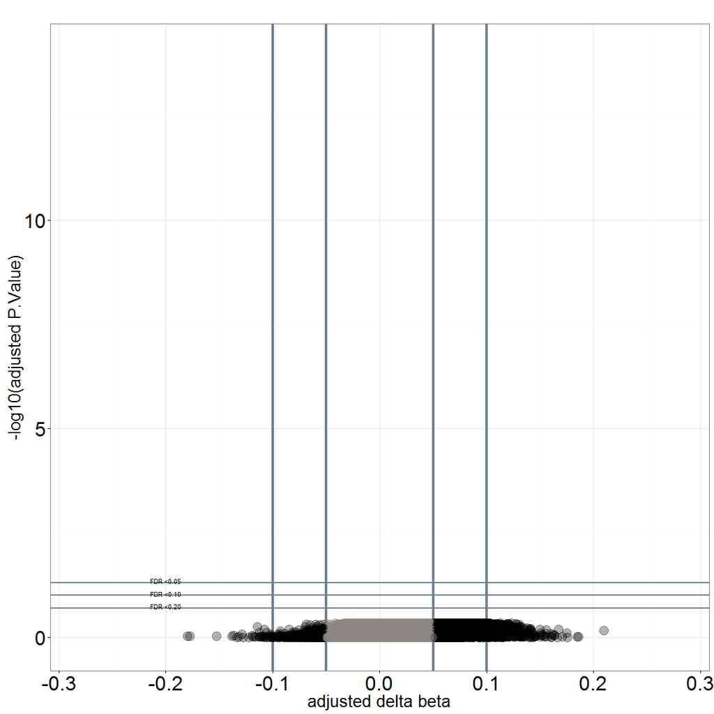

```r
##Volcano
library(scales)
##All data-females only
ttTS$FDR<- as.factor(ttTS$adj.P.Val < 0.05)
ttTS$beta<- as.factor(abs(ttbeta_all$TS) >= 0.05)
ttTS$both<- as.factor(abs(ttbeta_all$TS) >= 0.05 & ttTS$adj.P.Val < 0.05 )
ttTS$thres<-paste(substr(ttTS$FDR,1,1),substr(ttTS$beta,1,1),substr(ttTS$both,1,1))

Allsamples_TS_vol<-ggplot(ttTS, aes(x=ttbeta_all$TS, y=-log10(ttTS$adj.P.Val), color=as.factor(ttTS$beta))) +
  geom_vline(xintercept=c(-0.10,0.10), color="slategray", size=1.5) +
  geom_vline(xintercept=c(-0.05,0.05), color="slategray", size=1.5) +
  geom_hline(yintercept=(-log10(0.20)), color="slategray", size=1.0) +
  geom_hline(yintercept=(-log10(0.10)), color="slategray", size=1.0) +
  geom_hline(yintercept=(-log10(0.05)), color="slategray", size=1.0) +
  geom_point(shape=19, alpha=0.3, size=5) + theme_bw() +
  ylab("-log10(adjusted P.Value)") +
  xlab("adjusted delta beta")+
  scale_color_manual(values=c("seashell4","black"), guide=F) +
  coord_cartesian(xlim = c(-0.28, 0.28), ylim = c(-0.1,14))+
  ggtitle("")+
  annotate("text", -0.20,(-log10(0.045)) , label = "FDR <0.05", size=3)+
  annotate("text", -0.20,(-log10(0.09)) , label = "FDR <0.10", size=3)+
  annotate("text", -0.20,(-log10(0.18)) , label = "FDR <0.20", size=3)+
   theme(axis.text.x=element_text(size=24),
        axis.text.y=element_text(size=24),
        axis.title.x=element_text(size=20, vjust=-0.3),
        axis.title.y=element_text(size=20, vjust=2),
        plot.title=element_text(size=20, vjust=3))

Allsamples_TS_vol
```

Looking at Males

```r
##Linear model looking for association between DNAm and TL in males
DesMat <- model.matrix(~TS+GA, Des_M)##No need to correct for sex, only looking at females

##Pull out m-values
mDat<-PROJECT.M

Fit <- lmFit(mDat, DesMat)
EbFit <- eBayes(Fit)
ttTS<-topTable(EbFit,coef="TS", n= Inf)
print(head(ttTS))
```

```
##                 logFC    AveExpr         t      P.Value adj.P.Val
## cg21341008 -1.0129281  2.3361874 -5.604503 3.643902e-06 0.9274826
## cg16004911 -0.8265223 -4.9217811 -5.317305 8.341769e-06 0.9274826
## cg02335844 -1.0364713  2.0447998 -5.132696 1.420951e-05 0.9274826
## cg12614105 -0.6488276 -0.2963497 -5.100541 1.559034e-05 0.9274826
## cg05926478 -0.6227274  3.5029901 -5.098351 1.568913e-05 0.9274826
## cg26872792  0.8634139 -4.0894308  5.073457 1.685677e-05 0.9274826
##                     B
## cg21341008 -0.2250186
## cg16004911 -0.5105531
## cg02335844 -0.6988013
## cg12614105 -0.7319456
## cg05926478 -0.7342071
## cg26872792 -0.7599425
```

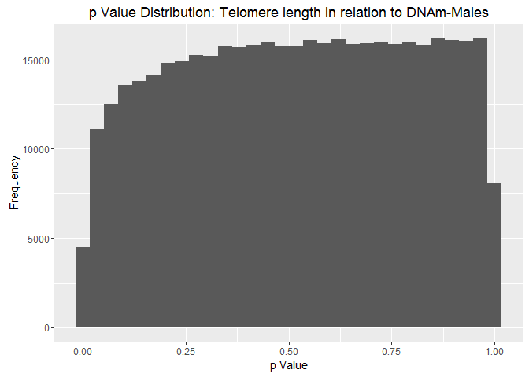

```r
##0 meet FDR

##For p-value distribution
tt<-topTable(EbFit,coef="TS", n=Inf)
ggplot(tt, aes(x =P.Value)) +
 geom_histogram() +
 theme_grey() +
   xlab("p Value") +
   ylab("Frequency") +
   ggtitle("p Value Distribution: Telomere length in relation to DNAm-Males")
```

Do they meet the delta beta threshold? Do any of these sites meet a delta beta threshold?

```r
## Do any sites meet an FDR<0.05, and delta beta>0.05
##Setting the FDR
cutoff.p = 0.05  # FDR threshold
hits_FDR = rownames(ttTS)[ttTS$adj.P.Val < cutoff.p]

##Pulling out change in DNAm
PROJECT.M_Beta<-m2beta(PROJECT.M)

fit_beta = lmFit(PROJECT.M_Beta, DesMat)
Ebfit_beta = eBayes(fit_beta)
ttbeta_all = topTable(Ebfit_beta, n = Inf)
```

```
## Removing intercept from test coefficients
```

```r
##Setting delta beta threshold
thresh = 0.05  # delta beta threshold
delta_beta= rownames(ttbeta_all)[abs(ttbeta_all$TS) > thresh]
length(delta_beta)##7590
```

```
## [1] 7590
```

```r
##7590 meet delta beta threshold

##Where do all these hits intersect?
delta_beta_intercept= intersect(delta_beta,hits_FDR)
##None meet the delta beta threshold AND FDR
```

Volcano plots

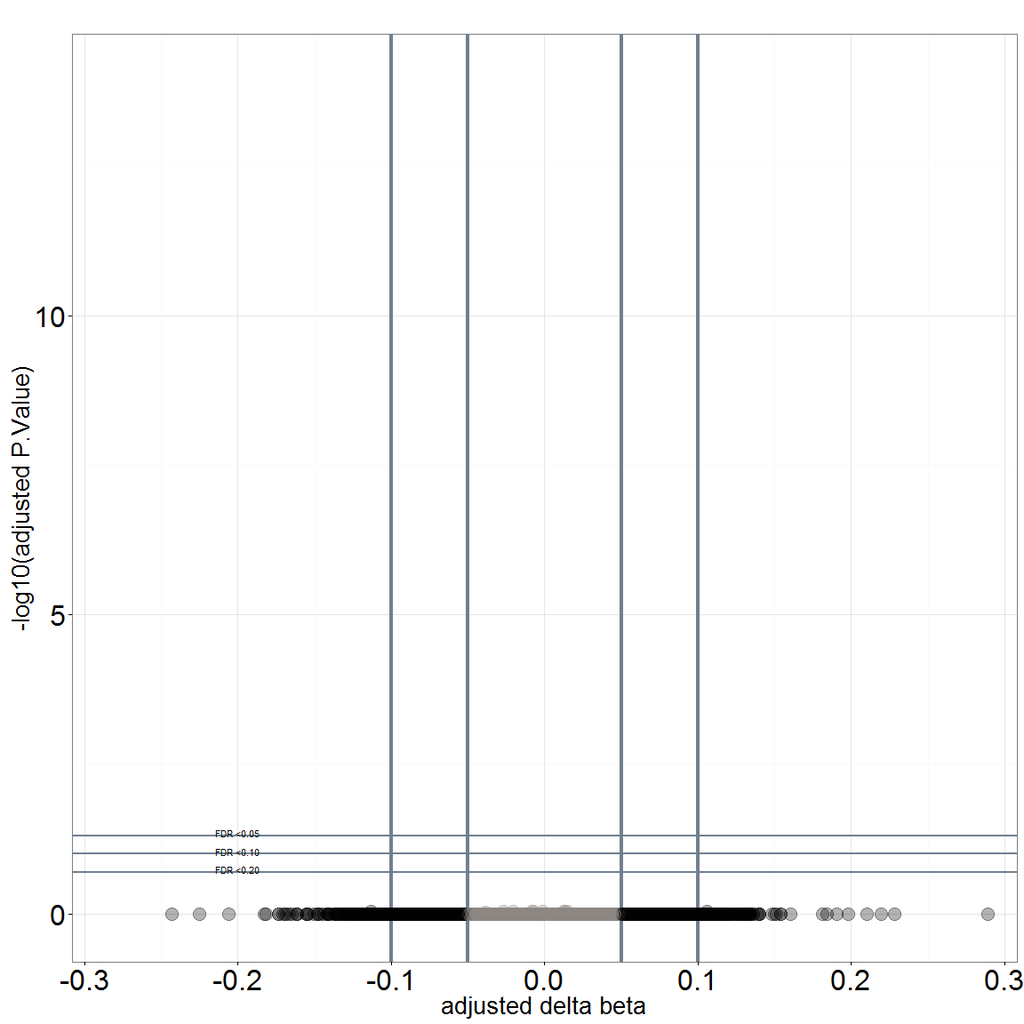

```r
##Volcano
##All data-Males only
ttTS$FDR<- as.factor(ttTS$adj.P.Val < 0.05)
ttTS$beta<- as.factor(abs(ttbeta_all$TS) >= 0.05)
ttTS$both<- as.factor(abs(ttbeta_all$TS) >= 0.05 & ttTS$adj.P.Val < 0.05 )
ttTS$thres<-paste(substr(ttTS$FDR,1,1),substr(ttTS$beta,1,1),substr(ttTS$both,1,1))

Allsamples_TS_M_vol<-ggplot(ttTS, aes(x=ttbeta_all$TS, y=-log10(ttTS$adj.P.Val), color=as.factor(ttTS$beta))) +
  geom_vline(xintercept=c(-0.10,0.10), color="slategray", size=1.5) +
  geom_vline(xintercept=c(-0.05,0.05), color="slategray", size=1.5) +
  geom_hline(yintercept=(-log10(0.20)), color="slategray", size=1.0) +
  geom_hline(yintercept=(-log10(0.10)), color="slategray", size=1.0) +
  geom_hline(yintercept=(-log10(0.05)), color="slategray", size=1.0) +
  geom_point(shape=19, alpha=0.3, size=5) + theme_bw() +
  ylab("-log10(adjusted P.Value)") +
  xlab("adjusted delta beta")+
  scale_color_manual(values=c("seashell4","black"), guide=F) +
  coord_cartesian(xlim = c(-0.28, 0.28), ylim = c(-0.1,14))+
  ggtitle("")+
  annotate("text", -0.20,(-log10(0.045)) , label = "FDR <0.05", size=3)+
  annotate("text", -0.20,(-log10(0.09)) , label = "FDR <0.10", size=3)+
  annotate("text", -0.20,(-log10(0.18)) , label = "FDR <0.20", size=3)+
   theme(axis.text.x=element_text(size=24),
        axis.text.y=element_text(size=24),
        axis.title.x=element_text(size=20, vjust=-0.3),
        axis.title.y=element_text(size=20, vjust=2),
        plot.title=element_text(size=20, vjust=3))

Allsamples_TS_M_vol
```